# Connor Voglewede’s HGU Analysis Project

Connor Voglewede

1/27/2019

## Introduction

The goal of this exercise to contruct a model that classifies individuals by likelihood of having a diagnosis of heart disease. The data was collected from an unknown source and includes 10 variables for each patient as well as the indicator of whether or not they were diagnosed with heart disease.

## Part 1: Cleaning and Exploring the Data

# Required Packages

I use a number of packages to clean, visualize, and model the data. Those packages are listed below:

```r
library(tidyverse)
library(dummies)
library(mice)
library(caTools)
library(caret)
library(stringr)
library(ROCR)
library(corrplot)
library(popbio)
library(GGally)
```

## Exploratory Data Analysis

```r
HGUdata_raw <- read.csv("HDdata.csv",header = TRUE)
head(HGUdata_raw)
```

```
##   age sex cp trestbps chol fbs restecg thalach exang oldpeak num
## 1  63   1  1      145  233   1       2     150     0     2.3   0
## 2  67   1  4      160  286   0       2     108     1     1.5   1
## 3  67   1  4      120  229   0       2     129     1     2.6   1
## 4  37   1  3      130  250   0       0     187     0     3.5   0
## 5  NA   0  2      130  204   0       2     172     0     1.4   0
## 6  56   1  2      120  236   0       0     178     0     0.8   0
```

The data is stored as a csv and can be read in use read.csv.

```r
str(HGUdata_raw)
```

```
## 'data.frame':    303 obs. of  11 variables:
##  $ age     : int  63 67 67 37 NA 56 62 57 63 53 ...
##  $ sex     : int  1 1 1 1 0 1 0 0 1 1 ...
##  $ cp      : int  1 4 4 3 2 2 4 4 4 4 ...
##  $ trestbps: int  145 160 120 130 130 120 140 120 130 140 ...
##  $ chol    : int  233 286 229 250 204 236 268 354 254 203 ...
##  $ fbs     : int  1 0 0 0 0 0 0 0 0 1 ...
##  $ restecg : int  2 2 2 0 2 0 2 0 2 2 ...
##  $ thalach : int  150 108 129 187 172 178 160 163 147 155 ...
##  $ exang   : int  0 1 1 0 0 0 0 1 0 1 ...
##  $ oldpeak : num  2.3 1.5 2.6 3.5 1.4 0.8 3.6 0.6 1.4 3.1 ...
##  $ num     : int  0 1 1 0 0 0 1 0 1 1 ...
```

```r
summary(HGUdata_raw)
```

```
##       age             sex               cp           trestbps
##  Min.   :29.00   Min.   :0.0000   Min.   :1.000   Min.   : 94.0
##  1st Qu.:48.00   1st Qu.:0.0000   1st Qu.:3.000   1st Qu.:120.0
##  Median :56.00   Median :1.0000   Median :3.000   Median :130.0
##  Mean   :54.48   Mean   :0.6799   Mean   :3.158   Mean   :131.7
##  3rd Qu.:61.00   3rd Qu.:1.0000   3rd Qu.:4.000   3rd Qu.:140.0
##  Max.   :77.00   Max.   :1.0000   Max.   :4.000   Max.   :200.0
##  NA's   :10
##       chol            fbs            restecg          thalach
##  Min.   :126.0   Min.   :0.0000   Min.   :0.0000   Min.   : 71.0
##  1st Qu.:211.0   1st Qu.:0.0000   1st Qu.:0.0000   1st Qu.:133.5
##  Median :241.0   Median :0.0000   Median :1.0000   Median :153.0
##  Mean   :246.7   Mean   :0.1485   Mean   :0.9901   Mean   :149.6
##  3rd Qu.:275.0   3rd Qu.:0.0000   3rd Qu.:2.0000   3rd Qu.:166.0
##  Max.   :564.0   Max.   :1.0000   Max.   :2.0000   Max.   :202.0
##
##      exang           oldpeak          num
##  Min.   :0.0000   Min.   :0.00   Min.   :0.0000
##  1st Qu.:0.0000   1st Qu.:0.00   1st Qu.:0.0000
##  Median :0.0000   Median :0.80   Median :0.0000
##  Mean   :0.3267   Mean   :1.04   Mean   :0.4587
##  3rd Qu.:1.0000   3rd Qu.:1.60   3rd Qu.:1.0000
##  Max.   :1.0000   Max.   :6.20   Max.   :1.0000
##
```

At first glance, the data already looks pretty clean. There are some missing age values that we’ll address later, but no other variables are missing data. There are several categorical variables encoded as numerical values, so we’ll work on encoding those most descriptively later.

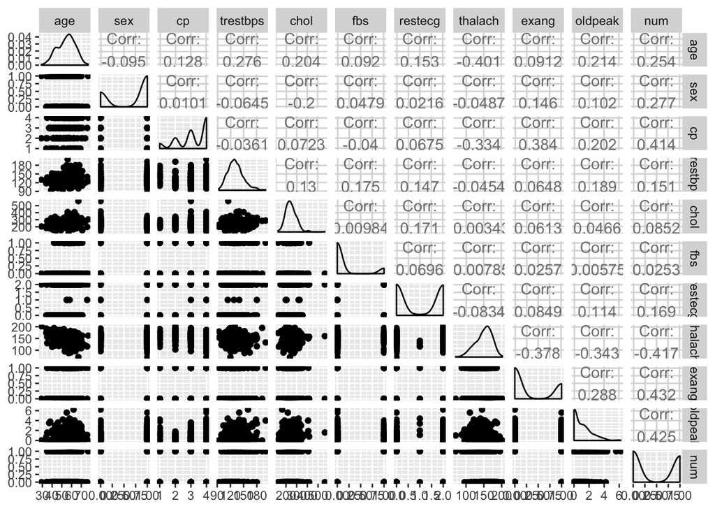

```r
ggpairs(HGUdata_raw)
```

```r
HGUdata_raw %>%
  summarise(patients=n(),cases=sum(num),rate=cases/patients)
```

```
##   patients cases      rate
## 1      303   139 0.4587459
```

The first thing I want to understand is the prevalence of the diagnosis rate of heart diseases to see if this is a balanced class problem or if heart diagnosis is a rare event. At 46% prevalence, I’m comfortable saying this dataset is balanced.

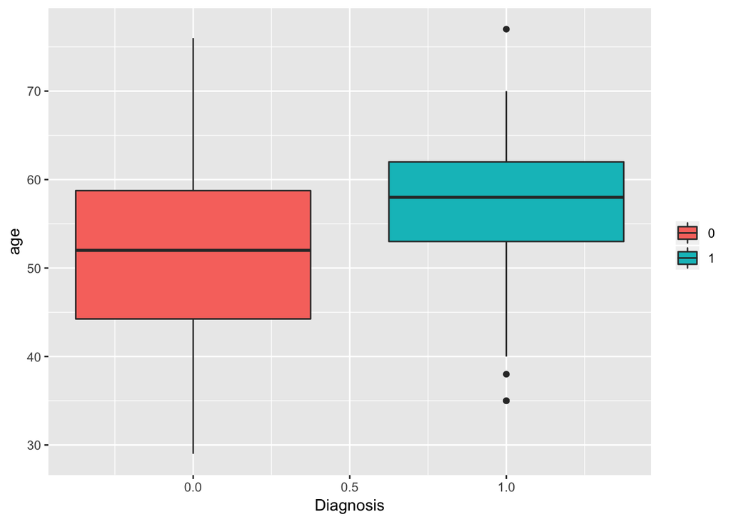

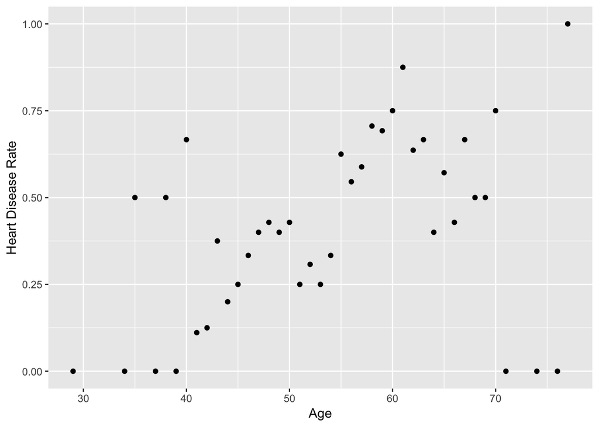

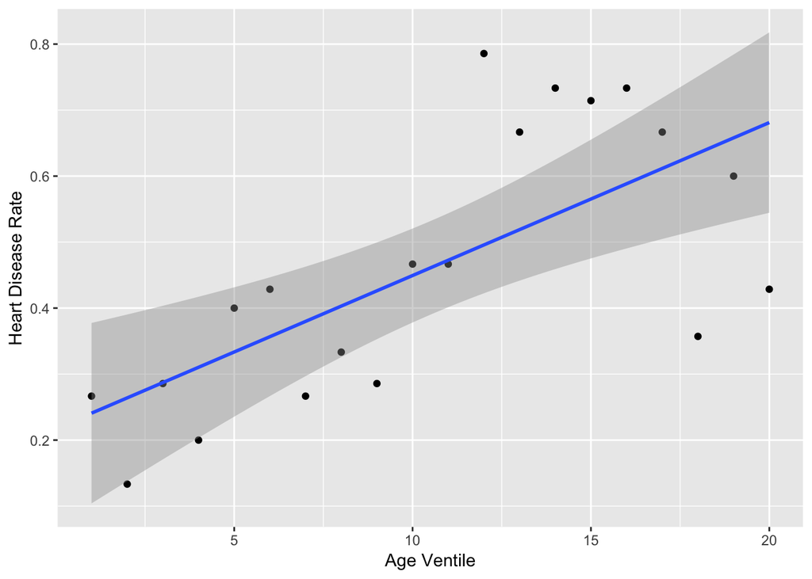

Going further, we can bin ages and look at the relationship between the bins and the rate of heart disease diagnosis. Binning by age value leads to some bins having a small sample size, but evidence is there for the positive relationship between age and diagnosis rate.

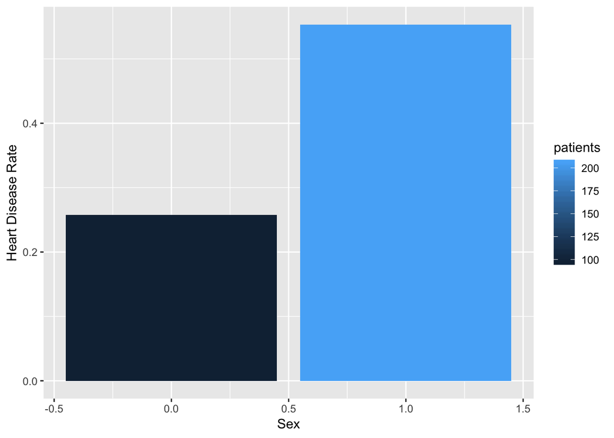

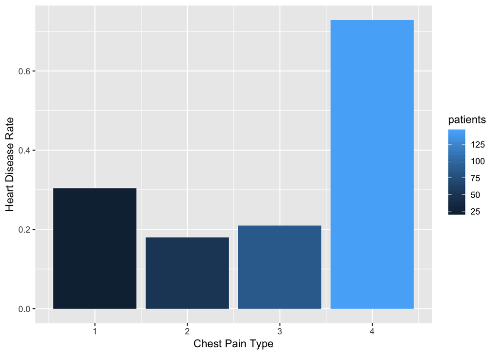

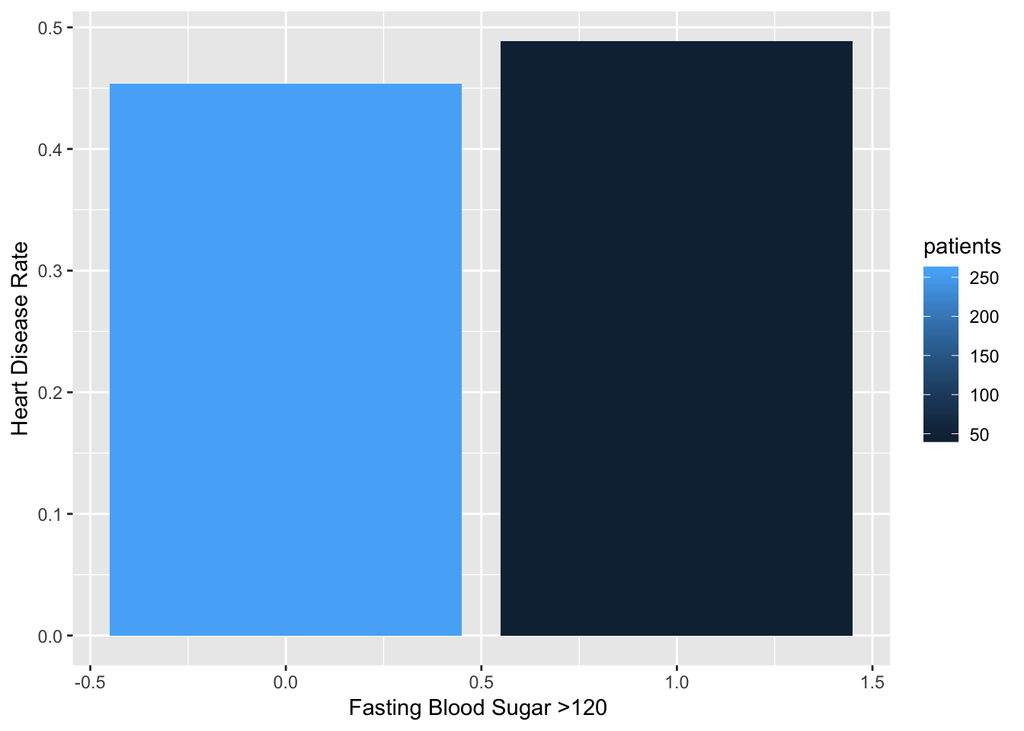

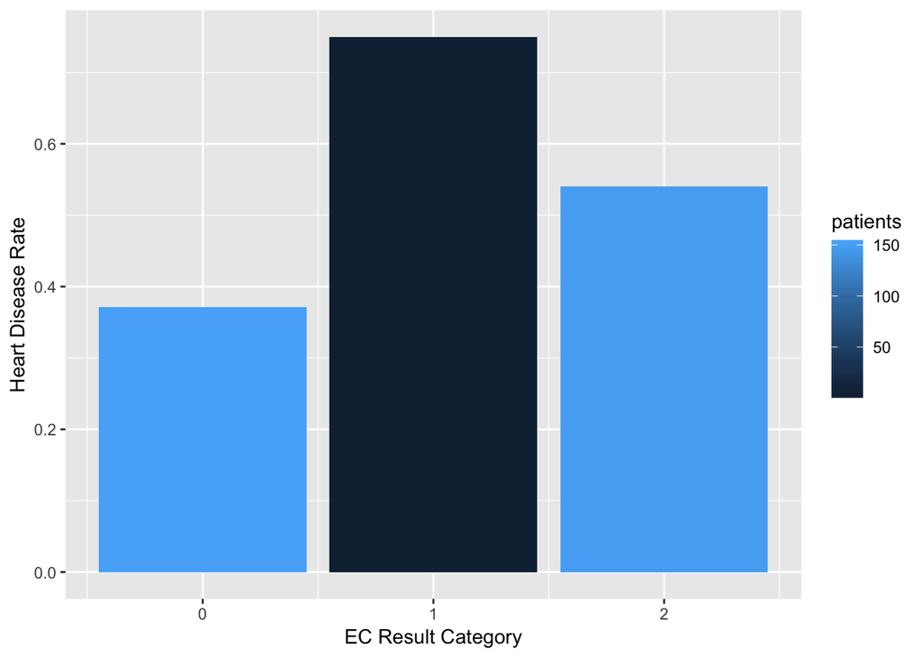

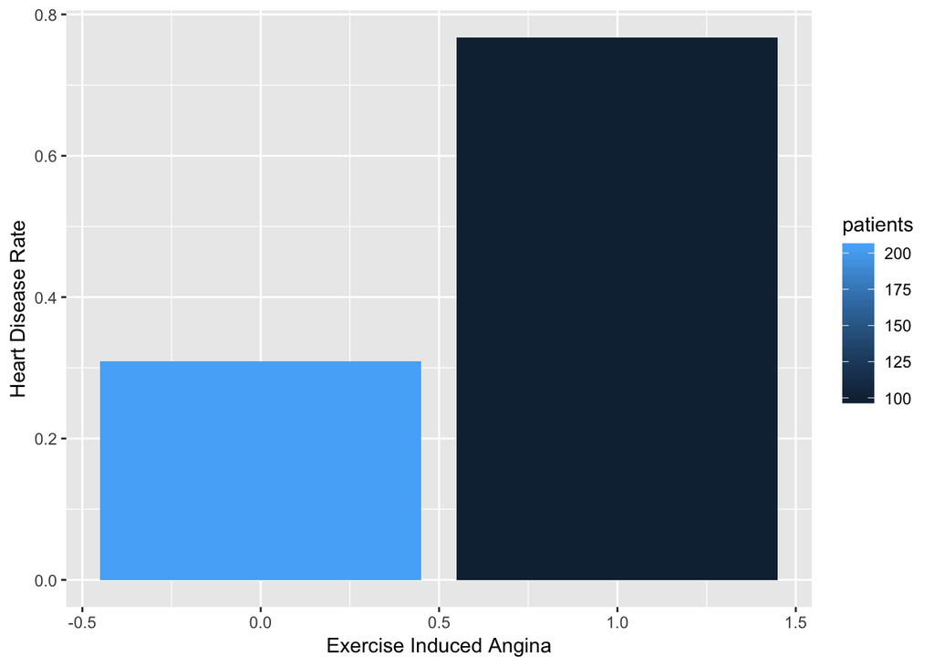

With these categorical variables, I wanted to get a sense not just how they correlate with the heart disease rate but also the distribution of patients within each variable. Of particular not, asymptomatic chest pain is strongly correlated with heart diseases, far moreso than other chest pain types. Also, male patients were diagnosed with heart disease at a rate almost twice of females.

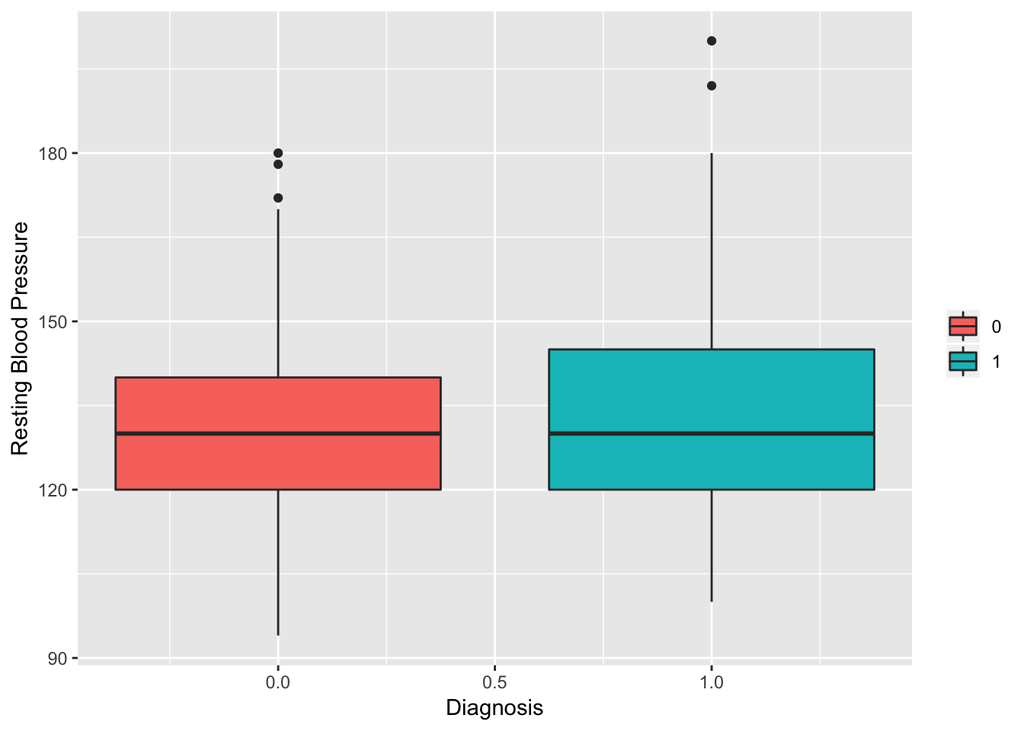

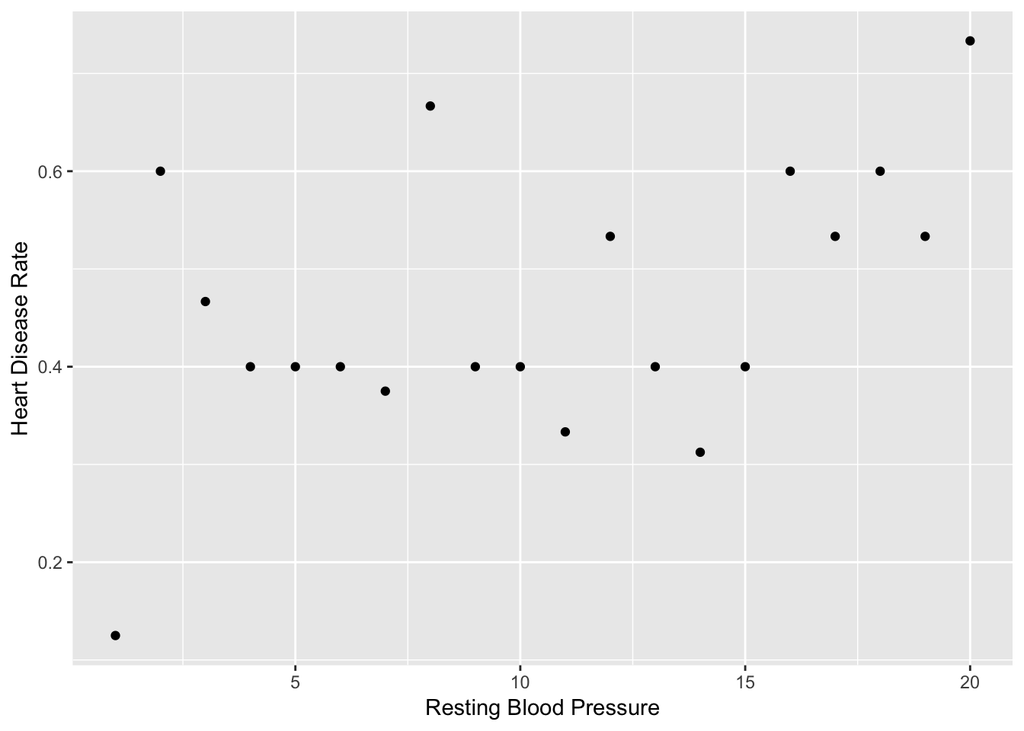

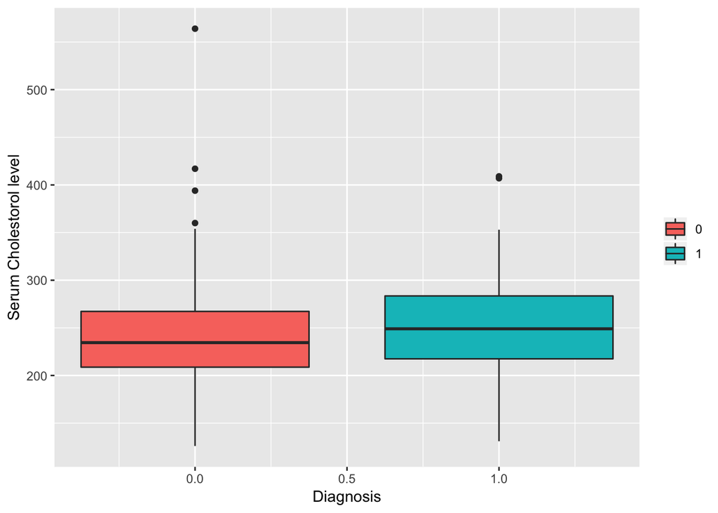

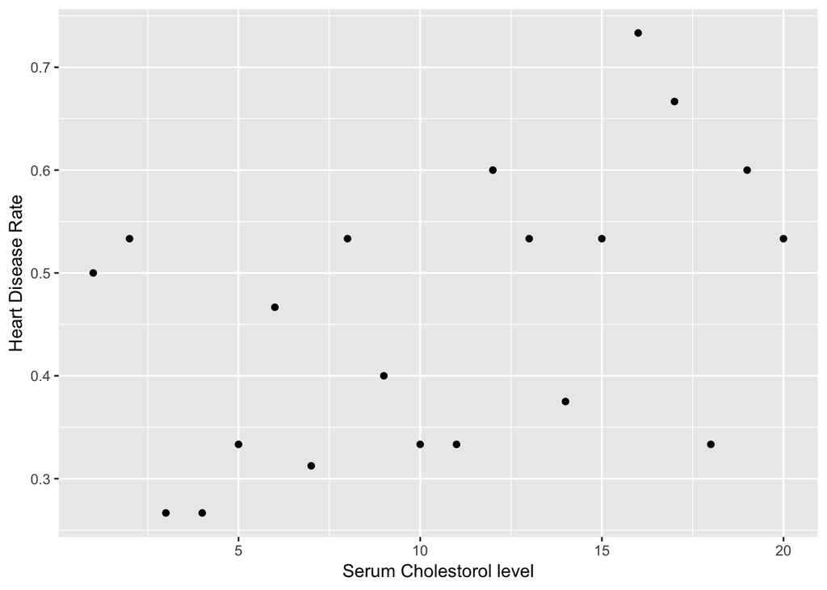

There doesn’t appear to be a strong relationship between resting blood pressure or cholestorol level and the rate of heart disease diagnosis. However, it seems that there is one cholestorol value that is an outlier relative to the rest of the sample.

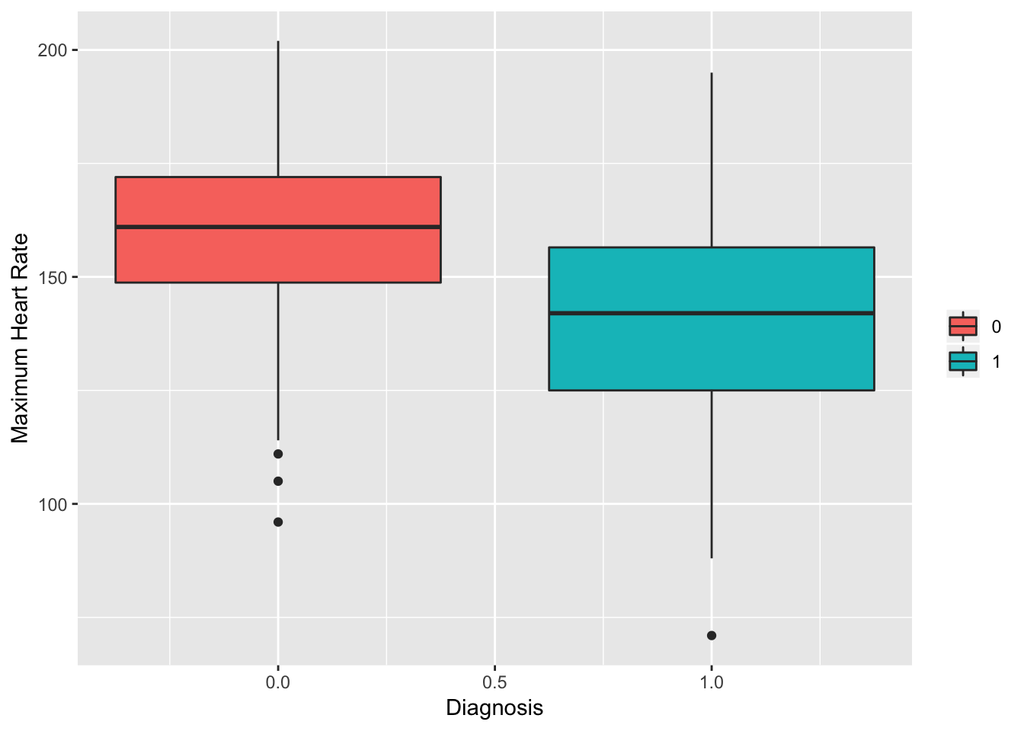

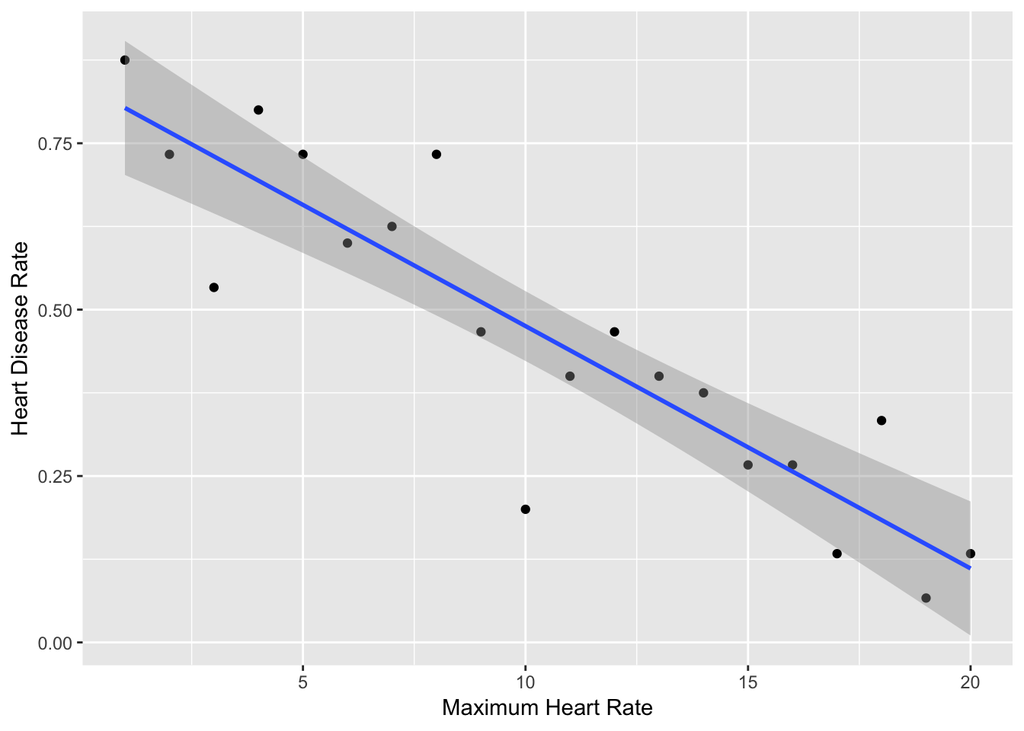

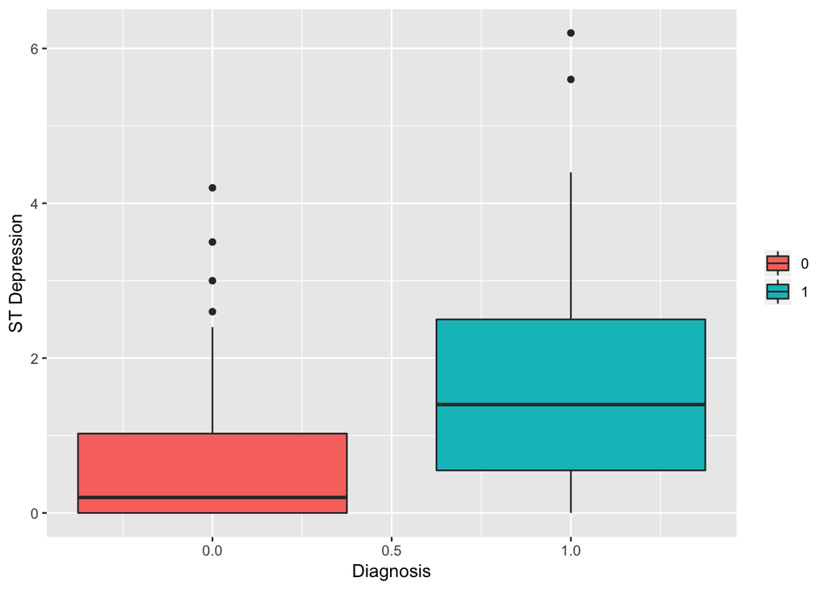

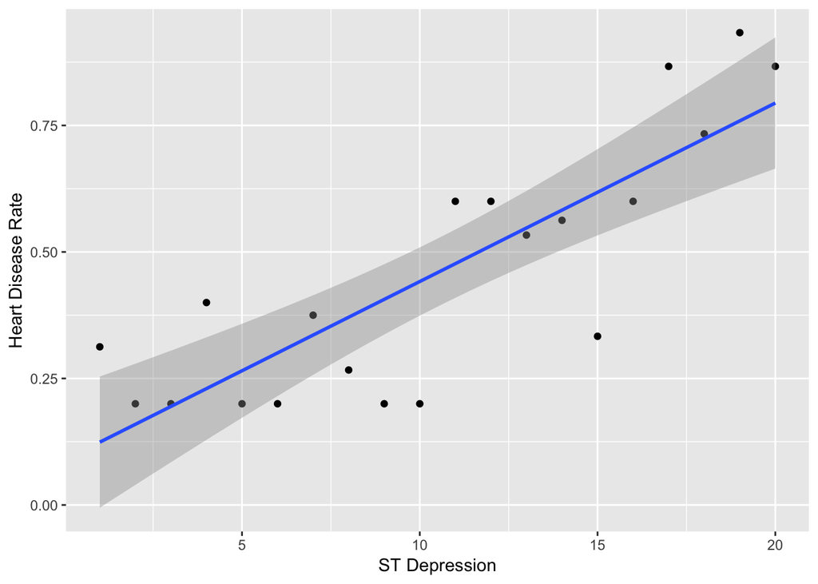

Both Maximum heart rate and ST Depression seem to have linear relationships with heart disease rate.

```r
max(HGUdata_raw$chol)
```

```
## [1] 564
```

```r
(max(HGUdata_raw$chol)-mean(HGUdata_raw$chol))/sd(HGUdata_raw$chol)
```

```
## [1] 6.128347
```

```r
HGUdata_raw <- HGUdata_raw[-246,]
```

I wanted to take a longer look at the outlier identified earlier. The high value of cholestorol level was 564 mg/dl, 6 standard deviations above the mean. I’m going to proactively remove this entry from the sample.

# Pre-Processing

Before I get to any treatment of the missing values, I want to re-assign the outcome varibale and categorical variables into factors with some more interpretable naming conventions as well.

```r
outcome <- factor(as.factor(HGUdata_raw$num),levels=c("0","1"))

sex_key <- c("1" = "male", "0" = "female")
cp_key <- c("1" = "typical angina", "2" = "atypical angina","3"="non_anginal pain", "4"="asymptomatic")
fbs_key <- c("1"="high fasting blood sugar","0"="low fasting blood sugar")
restecg_key <- c("0"="normal","1"="ST_T wave abnormality","2"="left ventricular hypertrophy")
exang_key <- c("1"="yes","0"="no")


HGUdata_pre <- HGUdata_raw %>%
  mutate(sex=as.factor(recode(sex,!!!sex_key))) %>%
  mutate(cp=as.factor(str_replace_all(recode(cp,!!!cp_key),"\\s+","_"))) %>%
  mutate(fbs=as.factor(str_replace_all(recode(fbs,!!!fbs_key),"\\s+","_"))) %>%
  mutate(restecg=as.factor(str_replace_all(recode(restecg,!!!restecg_key),"\\s+","_"))) %>%
  mutate(exang=as.factor(str_replace_all(recode(exang,!!!exang_key),"\\s+","_")))
```

# Missing Data

I am assuming that the missing values for age are Missing Completely at Random (MCAR). I will use predictive mean matching (PMM) from the mice package to impute the missing values for age. This method calculates multiple imputations (m=5) for the variable with missing data (age) and for each case where age is missing, pulls from observed value of age with predicted age nearby to the predicted value of the missing observed entry.

```r
set.seed(828)
imputed_Data <- mice(HGUdata_pre[,names(HGUdata_pre)!="num"], m=5, maxit =100, method = 'pmm', seed = 500)
HGUdata_complete <- complete(imputed_Data)
```

# Final Preparations for Modeling

This last step will be to encode dummy variables for the categorical variables sex, cp, fbs, restecg, and exang.

I’ll also drop the categorical variables from the dataset, as well as 1 variable from each dummy group (ex. Drop sex_female, keep sex_male).

```r
dummy_sex <- dummy(HGUdata_complete$sex,sep="_")
dummy_cp <- dummy(HGUdata_complete$cp,sep="_")
dummy_fbs <- dummy(HGUdata_complete$fbs,sep="_")
dummy_restecg <- dummy(HGUdata_complete$restecg,sep="_")
dummy_exang <- dummy(HGUdata_complete$exang,sep="_")

dummies <- cbind(dummy_sex,dummy_cp,dummy_fbs,dummy_restecg,dummy_exang)
```

```r
HGUdata_ready <- cbind(HGUdata_complete,dummies,outcome)

HGUdata_ready <- HGUdata_ready[ ,c(1,4,5,8,10,12,14,15,16,17,19,21,23,24)]
```

```r
head(HGUdata_ready)
```

```
##   age trestbps chol thalach oldpeak sex_male cp_atypical_angina
## 1  63      145  233     150     2.3        1                  0
## 2  67      160  286     108     1.5        1                  0
## 3  67      120  229     129     2.6        1                  0
## 4  37      130  250     187     3.5        1                  0
## 5  51      130  204     172     1.4        0                  1
## 6  56      120  236     178     0.8        1                  1
##   cp_non_anginal_pain cp_typical_angina fbs_high_fasting_blood_sugar
## 1                   0                 1                            1
## 2                   0                 0                            0
## 3                   0                 0                            0
## 4                   1                 0                            0
## 5                   0                 0                            0
## 6                   0                 0                            0
##   restecg_left_ventricular_hypertrophy restecg_ST_T_wave_abnormality
## 1                                    1                             0
## 2                                    1                             0
## 3                                    1                             0
## 4                                    0                             0
## 5                                    1                             0
## 6                                    0                             0
##   exang_yes outcome
## 1         0       0
## 2         1       1
## 3         1       1
## 4         0       0
## 5         0       0
## 6         0       0
```

## Part 2: Modeling and Results

# Split into Test/Train

I use the sample.split function to split by data into a training and test set. I have allocated 80% of my data to the training set.

```r
set.seed(9595)
train_ind <- sample.split(HGUdata_ready,SplitRatio = .8)
train <- subset(HGUdata_ready,train_ind ==TRUE)
test <- subset(HGUdata_ready,train_ind ==FALSE)
```

# Correlation Check

For one final check against any multicollinearity after encoding dummy variables, I’ve generated a correlation plot of the variables that will be used in the training data. There appears to be no risk of multicollinearity as no indepedent variable is highly correlated with another.

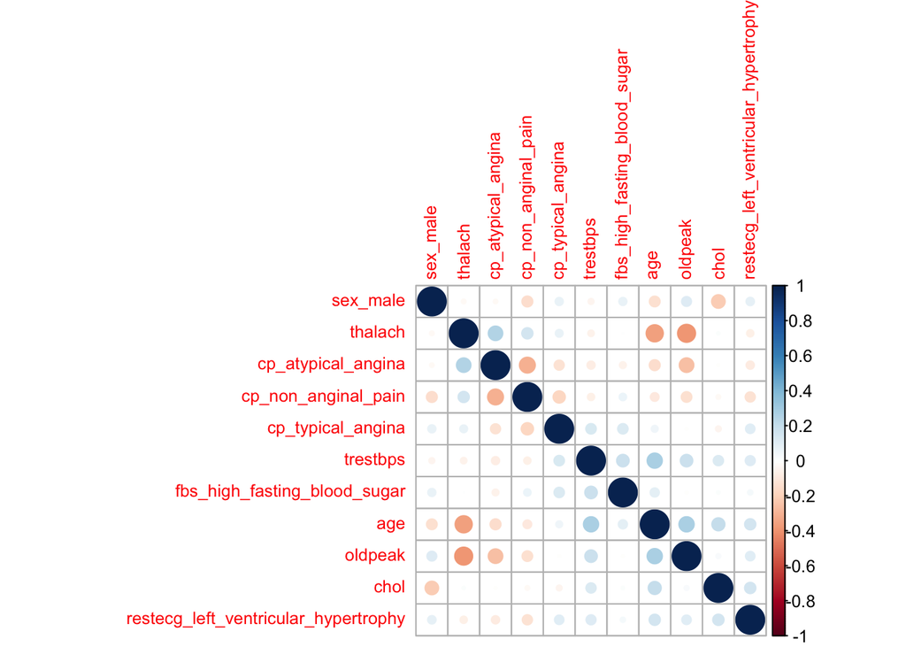

```r
corrplot::corrplot(cor(train[,1:11]),
                   order = "hclust",
                   tl.cex = .8)
```

# Logistic Regression - Train

The glm function can be used to fit a logistic regression model with outcome as the dependent variable.

```r
set.seed(1192)
model_logistic <- glm(outcome~.,data=train,family = binomial)
summary(model_logistic)
```

```
##
## Call:
## glm(formula = outcome ~ ., family = binomial, data = train)
##
## Deviance Residuals:
##     Min       1Q   Median       3Q      Max
## -2.7481  -0.6474  -0.2029   0.5252   2.5716
##
## Coefficients:
##                                       Estimate Std. Error z value Pr(>|z|)
## (Intercept)                          -5.828506   2.611879  -2.232  0.02565
## age                                   0.047724   0.025401   1.879  0.06027
## trestbps                              0.025574   0.011778   2.171  0.02991
## chol                                  0.007550   0.003913   1.930  0.05365
## thalach                              -0.025309   0.010983  -2.304  0.02121
## oldpeak                               0.679696   0.216065   3.146  0.00166
## sex_male                              2.109189   0.495512   4.257 2.08e-05
## cp_atypical_angina                   -1.301956   0.553370  -2.353  0.01863
## cp_non_anginal_pain                  -1.919313   0.478671  -4.010 6.08e-05
## cp_typical_angina                    -2.495015   0.767026  -3.253  0.00114
## fbs_high_fasting_blood_sugar         -0.147137   0.536155  -0.274  0.78375
## restecg_left_ventricular_hypertrophy  0.438389   0.383912   1.142  0.25349
## restecg_ST_T_wave_abnormality        -0.911964   2.356736  -0.387  0.69879
## exang_yes                             0.598743   0.451467   1.326  0.18477
##
## (Intercept)                          *
## age                                  .
## trestbps                             *
## chol                                 .
## thalach                              *
## oldpeak                              **
## sex_male                             ***
## cp_atypical_angina                   *
## cp_non_anginal_pain                  ***
## cp_typical_angina                    **
## fbs_high_fasting_blood_sugar
## restecg_left_ventricular_hypertrophy
## restecg_ST_T_wave_abnormality
## exang_yes
## ---
## Signif. codes:  0 '***' 0.001 '**' 0.01 '*' 0.05 '.' 0.1 ' ' 1
##
## (Dispersion parameter for binomial family taken to be 1)
##
##     Null deviance: 324.99  on 236  degrees of freedom
## Residual deviance: 184.41  on 223  degrees of freedom
## AIC: 212.41
##
## Number of Fisher Scoring iterations: 6
```

```r
train$prob_logistic <- predict(model_logistic, type="response")
classification_point <- .5
train$pred_class <- as.factor(ifelse(train$prob_logistic>classification_point,1,0))

confusion_matrix_logistic <- confusionMatrix(data = train$pred_class,
                                             reference = train$outcome, positive = "1")

confusion_matrix_logistic
```

```
## Confusion Matrix and Statistics
##
##           Reference
## Prediction   0   1
##          0 117  24
##          1  16  80
##
##                Accuracy : 0.8312
##                  95% CI : (0.7773, 0.8766)
##     No Information Rate : 0.5612
##     P-Value [Acc > NIR] : <2e-16
##
##                   Kappa : 0.6544
##  Mcnemar's Test P-Value : 0.2684
##
##             Sensitivity : 0.7692
##             Specificity : 0.8797
##          Pos Pred Value : 0.8333
##          Neg Pred Value : 0.8298
##              Prevalence : 0.4388
##          Detection Rate : 0.3376
##    Detection Prevalence : 0.4051
##       Balanced Accuracy : 0.8245
##
##        'Positive' Class : 1
##
```

I set a prediction threshold at 50%. For entries with >50% predicted probability of heart disease, I declared the predicted class to be “has heart disease”.

With these predicted classes generated, a confusion matrix can be generated with the confusionMatrix function and specifying the reference variable (outcome) and the positive case (=1).

From the function’s output, we can see many critical classification metrics pre-calculated. Accuracy is 83%, Sensitivity is 77%, Specificity is 88%, and Kappa is .65

```r
pr_logistic <- prediction(train$prob_logistic, train$outcome)
roc_logistic <- performance(pr_logistic, measure = "tpr", x.measure = "fpr")
auc_logistic <- performance(pr_logistic, measure = "auc")
auc_value_logistic <- auc_logistic@y.values[[1]]
auc_value_logistic
```

```
## [1] 0.903557
```

```
## integer(0)
```

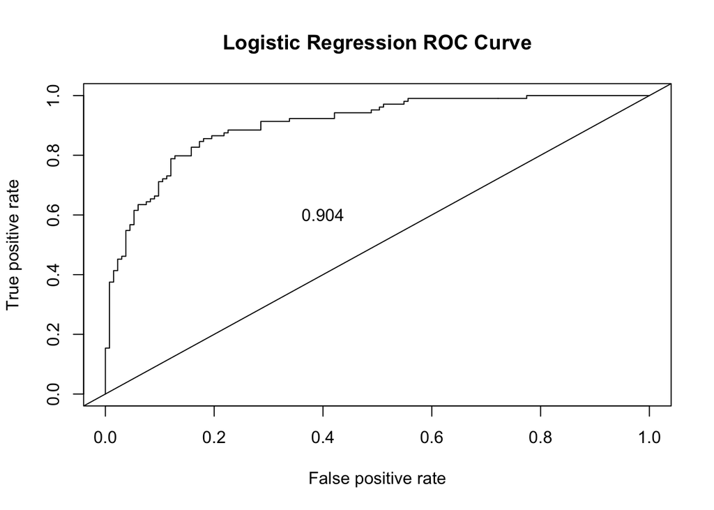

Further, I generated an ROC curve for the logistic model. The area under the curve is .904, a strong indicator of a good model fit at any prediction threshold.

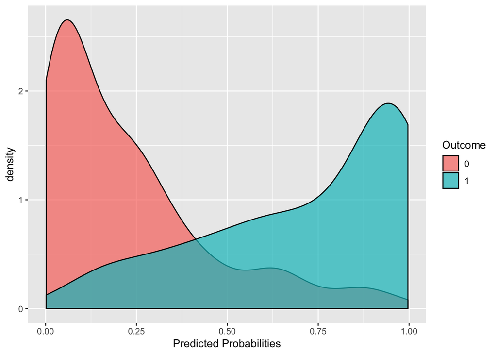

The above chart shows how the predicted probabilities in the training set closely match the actual heart disease outcomes.

# Logistic Regression - Test

```r
test$prob <- predict(model_logistic, newdata = test, type="response")
test$pred_class <- as.factor(ifelse(test$prob>classification_point,1,0))
confusion_matrix_test <- confusionMatrix(data = test$pred_class, reference = test$outcome,positive="1")
confusion_matrix_test
```

```
## Confusion Matrix and Statistics
##
##           Reference
## Prediction  0  1
##          0 25  8
##          1  6 26
##
##                Accuracy : 0.7846
##                  95% CI : (0.6651, 0.8769)
##     No Information Rate : 0.5231
##     P-Value [Acc > NIR] : 1.192e-05
##
##                   Kappa : 0.5695
##  Mcnemar's Test P-Value : 0.7893
##
##             Sensitivity : 0.7647
##             Specificity : 0.8065
##          Pos Pred Value : 0.8125
##          Neg Pred Value : 0.7576
##              Prevalence : 0.5231
##          Detection Rate : 0.4000
##    Detection Prevalence : 0.4923
##       Balanced Accuracy : 0.7856
##
##        'Positive' Class : 1
##
```

Now that we have a champion model, we can see how the model performs on the test holdout. The predict function will generate predicted probabilities on the test data and using our prediction threshold of .5, we can generate a confusion matrix for the model’s fit on the test data.

As expected, it’s a similar fit: Accuracy = 78%, Sensitivity = 76%, Specificity = 81%, and Kappa = .57.

The logistic model does appear to do worse on the test data than the training data at the threshold of .5

However, I’d like to compare the areas under the ROC curve to understand how the model performs at all possible prediction thresholds.

```r
pr_test <- prediction(test$prob, test$outcome)
roc_test <- performance(pr_test, measure = "tpr", x.measure = "fpr")
auc_test <- performance(pr_test, measure = "auc")
auc_value_test <- auc_test@y.values[[1]]
auc_value_test
```

```
## [1] 0.8614801
```

```
## integer(0)
```

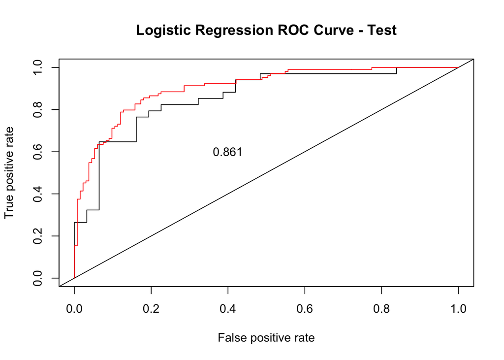

In red, I’ve brought in the ROC curve from the training data fit. There are many more data points in the training data, so the curve has more data points for the true positive rate and false positive rates to change.

Regardless, I was looking to confirm that the test ROC curve looked visually close to the training ROC curve, and it does.

# Manually Calculate Accuracy, PPV, NPV, Sensitivity, and Specificity.

As requested in the project prompt, I will manually calculate some classification model performance metrics.

```r
event <- test$outcome == 1
predict <- test$prob > classification_point
TP <- sum(predict & event)
TN <- sum(!predict & !event)
FP <- sum(predict & !event)
FN <- sum(!predict & event)
n <- length(predict)
sensitivity_manual <-  TP/(TP+FN)
specificity_manual <- (TN)/(FP+TN)
prevalence_manual <- (TP+FN)/n
accuracy_manual <- (TP+TN)/n
PPV_manual <- (TP)/(TP+FP)
NPV_manual <- (specificity_manual*(1-prevalence_manual))/((prevalence_manual*(1-sensitivity_manual)+(1-prevalence_manual)*specificity_manual))

metrics <- list(
  prevalence_manual = prevalence_manual,
  accuracy_manual = accuracy_manual,
  sensitivity_manual = sensitivity_manual,
  specificity_manual = specificity_manual,
  PPV_manual = PPV_manual,
  NPV_manual = NPV_manual
)
metrics
```

```
## $prevalence_manual
## [1] 0.5230769
##
## $accuracy_manual
## [1] 0.7846154
##
## $sensitivity_manual
## [1] 0.7647059
##
## $specificity_manual
## [1] 0.8064516
##
## $PPV_manual
## [1] 0.8125
##
## $NPV_manual
## [1] 0.7575758
```

As expected, the outputs from the test data confusion matrix match the values of the calculated metrics

## Part 3: Next Steps

While this is a good model to fit the task at hand, I think it’d be very easy to produce additional models to compare against the logistic regression model. This data ready for LDA regression or a tree-based method. Perhaps another model or the addition of a spline would be able to pick up on the nonlinear relationship between age and heart disease rate.